# Logistic Regression

Kalle Karvonen

2023-11-20

# Logistic Regression

```r
#using the file I made in data wrangling
getwd()
```

```
## [1] "C:/Users/Kalka/OneDrive/Desktop/Random/School/Open_Data/IODS-project"
```

```r
alc <- read.csv("alc.csv")
colnames(alc)
```

```
##  [1] "school"     "sex"        "age"        "address"    "famsize"
##  [6] "Pstatus"    "Medu"       "Fedu"       "Mjob"       "Fjob"
## [11] "reason"     "guardian"   "traveltime" "studytime"  "schoolsup"
## [16] "famsup"     "activities" "nursery"    "higher"     "internet"
## [21] "romantic"   "famrel"     "freetime"   "goout"      "Dalc"
## [26] "Walc"       "health"     "paid"       "failures"   "absences"
## [31] "G1"         "G2"         "G3"         "alc_use"    "high_use"
```

- This dataset consists of the variables shown above taken from students of a math and portuguese class and their performance. Data also has alcohol consumption added to it
- Daily alcohol consumption Dalc and Weekend alkohol consumption Walc from which alc_use is calculated by taking the average of the two. high_use is True if over the average is over 2 and False if under 2
- We will use this data to study the relationship between alcohol consumption and other variables in the data

For example if we expect men to be more likely to consume high amounts of alcohol and we want to use this data to test if there is a difference between alcohol consumption (high or low between the genders) we could do it like this

```r
# access the tidyverse packages dplyr and ggplot2
library(dplyr); library(ggplot2)
# First summarize the data a bit to see what to expect
alc %>% group_by(sex,high_use) %>% summarise(count = n())
```

[output not shown]

```
## # A tibble: 4 × 3
## # Groups:   sex [2]
##   sex   high_use count
##   <chr> <lgl>    <int>
## 1 F     FALSE      154
## 2 F     TRUE        41
## 3 M     FALSE      105
## 4 M     TRUE        70
```

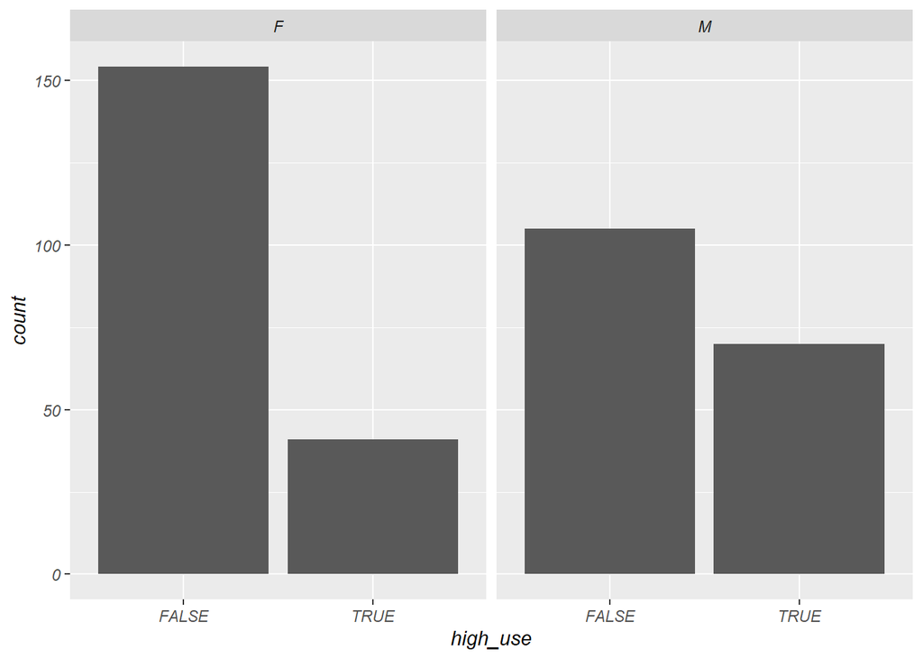

```r
#Based on this we could already see that there will be a difference

# Plot the differences
g1 <- ggplot(data = alc, aes(x=high_use))
# draw a bar plot of high_use by sex
g1+geom_bar()+facet_wrap("sex")
```

-Based on this we could say that more men consume high amounts of alcohol when compared to women”

-similarily here is a different type of plot for alcohol usage (high or low) and age - it is expected that alcohol consumption should be low for underage people and that we get more high alcohol use people with higher ages

```r
alc %>% group_by(high_use,age) %>% summarise(count = n())
```

```
## # A tibble: 12 × 3
## # Groups:   high_use [2]
##    high_use   age count
##    <lgl>    <int> <int>
##  1 FALSE       15    63
##  2 FALSE       16    74
##  3 FALSE       17    62
##  4 FALSE       18    52
##  5 FALSE       19     7
##  6 FALSE       20     1
##  7 TRUE        15    18
##  8 TRUE        16    28
##  9 TRUE        17    35
## 10 TRUE        18    25
## 11 TRUE        19     4
## 12 TRUE        22     1
```

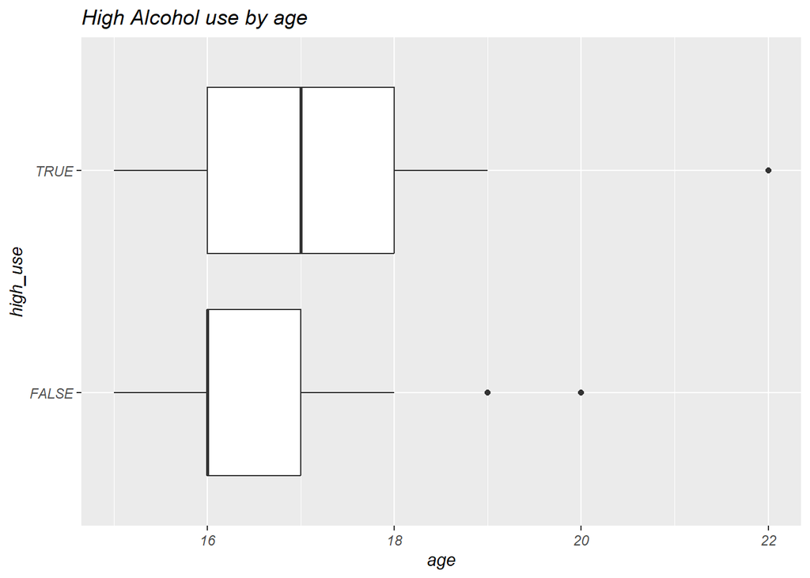

```r
# initialize a plot of high_use and age
g2 <- ggplot(alc,aes(x=age,y=high_use))
g2+geom_boxplot()+ggtitle("High Alcohol use by age")
```

```r
# define the plot as a box plot and draw it
```

```r
# find the model with glm()
m <- glm(high_use ~ sex, data = alc, family = "binomial")
n <- glm(high_use~age,data=alc,family="binomial")

# print out a summary of the model
summary(m)
```

```
##
## Call:
## glm(formula = high_use ~ sex, family = "binomial", data = alc)
##
## Coefficients:
##             Estimate Std. Error z value Pr(>|z|)
## (Intercept)  -1.3234     0.1757  -7.530 5.06e-14 ***
## sexM          0.9179     0.2339   3.925 8.67e-05 ***
## ---
## Signif. codes:  0 '***' 0.001 '**' 0.01 '*' 0.05 '.' 0.1 ' ' 1
##
## (Dispersion parameter for binomial family taken to be 1)
##
##     Null deviance: 452.04  on 369  degrees of freedom
## Residual deviance: 436.13  on 368  degrees of freedom
## AIC: 440.13
##
## Number of Fisher Scoring iterations: 4
```

```r
summary(n)
```

```
##
## Call:
## glm(formula = high_use ~ age, family = "binomial", data = alc)
##
## Coefficients:
##             Estimate Std. Error z value Pr(>|z|)
## (Intercept) -4.07538    1.60980  -2.532   0.0114 *
## age          0.19414    0.09628   2.016   0.0438 *
## ---
## Signif. codes:  0 '***' 0.001 '**' 0.01 '*' 0.05 '.' 0.1 ' ' 1
##
## (Dispersion parameter for binomial family taken to be 1)
##
##     Null deviance: 452.04  on 369  degrees of freedom
## Residual deviance: 447.94  on 368  degrees of freedom
## AIC: 451.94
##
## Number of Fisher Scoring iterations: 4
```

```r
# print out the coefficients of the model
coef(m)
```

```
## (Intercept)        sexM
##  -1.3233805   0.9179154
```

```r
coef(n)
```

```
## (Intercept)         age
##  -4.0753783   0.1941355
```

- as you can see above both sex and age seem to have some capability of predicting high alcohol use. Note that in the sex part the model only shows the Males because of how R handles categorical variables by performing dummy coding. In this case the sexF has been used as a reference class for sexM

all the p values in both tests (age and sex) show that there is a statistical significance although age does not seem to be so strong predictor of high alcohol use as sex and it is probably not a very good predictor to use.

- How about odds ratio and its confidence interval.

```r
# compute odds ratios (OR)
ORm <- coef(m) %>% exp

# compute confidence intervals (CI)
CIm <- confint(m)
# print out the odds ratios with their confidence intervals
cbind(ORm, CIm)
```

```
##                   ORm      2.5 %     97.5 %
## (Intercept) 0.2662338 -1.6802691 -0.9894944
## sexM        2.5040650  0.4639196  1.3822585
```

- Here from the odd ratios we see that the odds ratios do not go in the confidence interval showing statistical significance. from the odds ratio we can also show correlation with the intercept ( alcohol usage) namely the positive odds ratio of 2.5 tells us that high alcohol usage is 2.5 times more probable on males than females ( females used as a reference state)

```r
ORn <- coef(n) %>% exp
CIn <- confint(n)
cbind(ORn,CIn)
```

```
##                    ORn        2.5 %     97.5 %
## (Intercept) 0.01698579 -7.271045604 -0.9407959
## age         1.21426075  0.006116096  0.3847577
```

- similarily to above here we also see some correlation between age and high alcohol consumption but this time only 1.2 times as high. Because we are talking of continuous variable such as age every increase in age should raise the odds of being a high alcohol user by 1.2. When we think about it this is not feasible since alcohol consumption does not grow exponentially as we age. so Age might not be a good model even though in this case it is statistically significant. Also to note is that this cohort was partly underage and they cannot legally buy alcohol so data might not be reliable in that sense.
- Testing the predictitive power of these modesl

```r
probabilities_m <- predict(m, type = "response")
probabilities_n <- predict(n,type = "response")
alc <- mutate(alc, probability_sex = probabilities_m)
alc <- mutate(alc, probability_age = probabilities_n)
#now we have the predictions here and we can use them to predict a treshold of for example 0.5
alc <- mutate(alc, predicted_high_use_sex = ifelse(probability_sex > 0.5, TRUE, FALSE))
alc <- mutate(alc, predicted_high_use_age = ifelse(probability_age > 0.5, TRUE, FALSE))

# Now we can print these into their own 2x2 crosstables to see how they worked
Alcohol_Sex <- table(High_Use=alc$high_use, Prediction=alc$predicted_high_use_sex)
print(Alcohol_Sex)
```

```
##         Prediction
## High_Use FALSE
##    FALSE   259
##    TRUE    111
```

```r
Alcohol_Age <- table(High_Use=alc$high_use, Prediction=alc$predicted_high_use_age)
print(Alcohol_Age)
```

```
##         Prediction
## High_Use FALSE TRUE
##    FALSE   259    0
##    TRUE    110    1
```

```r
date()
```

```
## [1] "Tue Nov 21 05:17:28 2023"
```